# Homework 2

Sasikanth Nagalla

13 April 2016

**Question 1: Bivariate Normal Random**

```r
lgm <- function(n,x0){
  a <- 7^5
  b <- 0
  m <- 2^31 - 1
  rand <- numeric(n)
  rand[1] <- x0
  for (i in 2:n) {
    rand[i] = (rand[i-1]*a)%%m
  }
  return (rand/m)
}

simnorm <- function(n,m){
unimatrix <- matrix(lgm(n,m),n/2,2)
Zone <- sqrt(-2*log(unimatrix[,1]))*cos(2*pi*unimatrix[,2])
Ztwo <- sqrt(-2*log(unimatrix[,1]))*sin(2*pi*unimatrix[,2])
Z <- c(Zone, Ztwo)
return (Z)
}

simmvn <- function(n,m,mu,Sigma){
rho <- Sigma[1,2]
Z <- matrix(simnorm(2*n,m),ncol=2)
X <- mu[1] + Sigma[1,1]*Z[,1]
Y <- mu[2] + rho*Sigma[2,2]*X + sqrt(1-rho^2)*Sigma[2,2]*Z[,2]
return (cbind(X,Y))
}

# Correlation
Sigma <- matrix(c(1,-0.7,-0.7,1),2,2)
mu <- c(0,0)
data <- matrix(simmvn(n = 10000, 0.001,mu, Sigma), ncol =2)
xbar <- data[,1] - mean(data[,1])
ybar <- data[,2] - mean(data[,2])
correlation <- sum(xbar*ybar)/sqrt(sum(xbar*xbar)*sum(ybar*ybar))
```

The value of $\rho$ is: -0.7043615

**Question 2: Monte Carlo Simulation**

```r
Sigma <- matrix(c(1,0.6,0.6,1),2,2)
mu <- c(0,0)
data<- matrix(simmvn(n = 10000,0.001, mu, Sigma),ncol=2)

func <-function(X,Y){
return (X^3 + sin(Y) + Y*X^2)
}

temp = 0
for (i in 1:nrow(data)){
temp = temp + max(0,func(data[i,1],data[i,2]))
}

E <- temp/i
```

The value of E is: 1.5439161

**Question 3**  
**3.a**

```r
n <- 100000
rand <- simnorm(n,2)
a1 <- 5*rand^2 + sin(rand*sqrt(5))
Ea1 <- sum(a1)/n
a2 <- exp(0.5/2) * cos(rand*sqrt(0.5))
Ea2 <- sum(a2)/n
a3 <- exp(3.2/2) * cos(rand*sqrt(3.2))
Ea3 <- sum(a3)/n
a4 <- exp(6.5/2) * cos(rand*sqrt(6.5))
Ea4 <- sum(a4)/n

var(a1)
```

```
## [1] 51.06435
```

```r
var(a2)
```

```
## [1] 0.1283656
```

```r
var(a3)
```

```
## [1] 11.34109
```

```r
var(a4)
```

```
## [1] 332.5487
```

Ea1 : 5.0247868  
Ea2 : 0.9988549  
Ea3 : 0.9924087  
Ea4 : 1.0283125

**3.b**  
The values of the last three integrals are equal to one since there are independent of t and equal to 1.

**3.c** **variance reduction technique**

```r
ran <- -rand
b1 <- (5*ran^2 + sin(ran*sqrt(5)) + a1)/2
Eb1 <- sum(b1)/n
b2 <- (exp(0.5/2) * cos(ran*sqrt(0.5)) + a2)/2
Eb2 <- sum(b2)/n
b3 <- (exp(3.2/2) * cos(ran*sqrt(3.2)) + a3)/2
Eb3 <- sum(b3)/n
b4 <- (exp(6.5/2) * cos(ran*sqrt(6.5)) + a4)/2
Eb4 <- sum(b4)/n

var(b1)
```

```
## [1] 50.57551
```

```r
var(b2)
```

```
## [1] 0.1283656
```

```r
var(b3)
```

```
## [1] 11.34109
```

```r
var(b4)
```

```
## [1] 332.5487
```

Eb1 : 5.0230352  
Eb2 : 0.9988549  
Eb3 : 0.9924087  
Eb4 : 1.0283125  
I used the antithetic variates for variance reduction but the results have not improved and the variance have remained the same except in the case of Ea1. Variance reduction technique gave improved result Eb1.

**Question 4**

**4.a**

```r
n <- 10000
r <- 0.04
sigma <- 0.2
K <- 100
s0 <- 88
T <- 5
rand <- simnorm(n,0.001)
price <- numeric()
for (i in 1:length(rand)){
price[i] <- exp(-r*T)*max(0,s0*(exp((r-0.5*sigma^2)*T + sigma*sqrt(T)*rand[i])) - K)
}
Ca1 <- mean(price)
var(price)
```

```
## [1] 1134.466
```

Ca1 : 18.817809  
variance : 1134.4659406

**4.b**

```r
library("OptionPricing")
price2 <- numeric()
for (j in 1:length(rand)){
price2[j] <- 0.5*(price[j] + exp(-r*T)*max(0,s0*exp((r-0.5*sigma^2)*T + sigma*sqrt(T)*(-rand[j])) - K))
}
Ca2 <- mean(price2)
var(price2)
```

```
## [1] 503.1248
```

```r
blsprice <- BS_EC(5,100,0.04,0.2,88)[1]
```

The black scholes price is: 18.2837657  
Ca2: 18.7450547  
variance : 503.1248323  
The variance reduction technique using antithetic variates has reduced the variance and improved the accuracy of the result.

**Question 5**

**5.a**

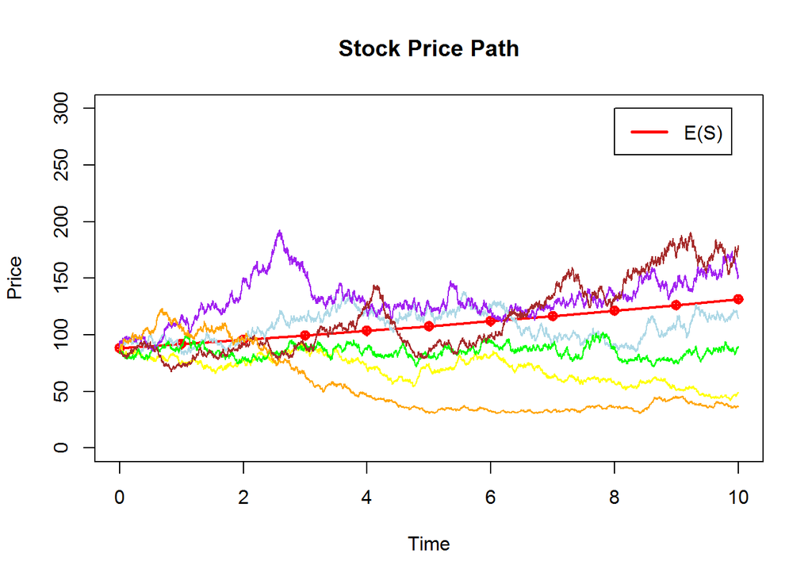

```r
S0 <- 88
sigma <- 0.18
r <- 0.04
n <- 10
nsims <- 10000
S <- matrix(NA,nrow=nsims,ncol=10)
for (i in 1:n){
Z <- simnorm(nsims,0.01)
S[,i] <- S0 * exp(sigma*sqrt(i)*Z + (r-0.5*sigma^2)*i)
}
ES <- c(S0,colMeans(S))
plot(0:n,ES,ylim=c(0,300),main="Stock Price Path", xlab= "Time", ylab="Price", type ='o', col = "red", pch=10, lty = 1, lwd =2)
legend(8,300,c("E(S)"),col=("red"), lty=c(1), lwd=c(2.5))

## simulate stock paths
library(sde)
suppressWarnings(suppressMessages(library(sde)))
t<- n/nsims
simS <- matrix(NA,ncol=7, nrow = nsims+1)
simS[,7] <- seq(0,10,10/nsims)
col <- c("lightblue","yellow","green","purple","brown","orange")
for (j in 1:6) {
#simS[,j] <- GBM(S0,r,sigma,T=10,N=1000)
simS[,j] <- S0*cumprod(1+ c(0,(r-sigma*sigma*0.5)*t + sigma*sqrt(t)*simnorm(nsims,j/10)))
lines(simS[,7],simS[,j],type='l', col=col[j])
}
```

**5.d**

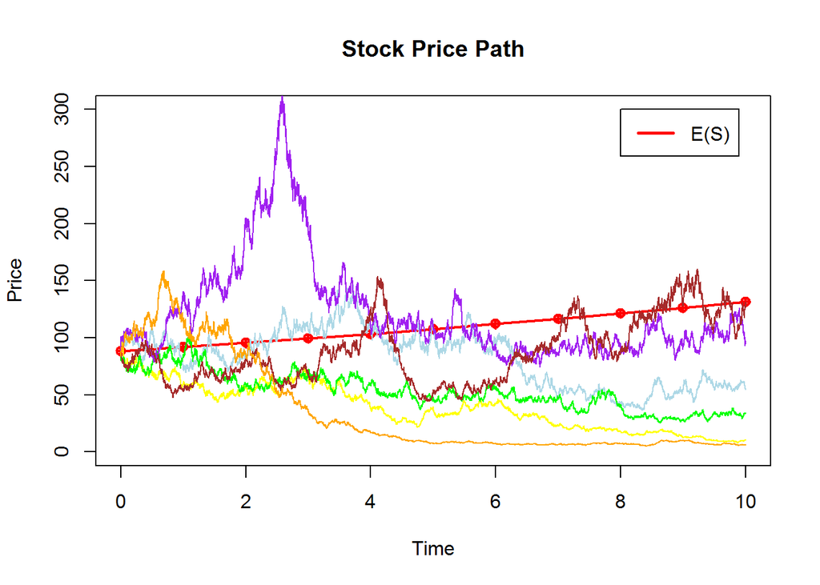

```r
sigma <- 0.35
nsims <- 10000
S <- matrix(NA,nrow=nsims,ncol=10)
for (i in 1:n){
Z <- simnorm(nsims,0.01)
S[,i] <- S0 * exp(sigma*sqrt(i)*Z + (r-0.5*sigma^2)*i)
}
ES <- c(S0,colMeans(S))
plot(0:n,ES,ylim=c(0,300),main="Stock Price Path", xlab= "Time", ylab="Price", type ='o', col = "red", pch=10, lty = 1, lwd =2)
legend(8,300,c("E(S)"),col=("red"), lty=c(1), lwd=c(2.5))

## simulate stock paths
library(sde)
t<- n/nsims
simS <- matrix(NA,ncol=7, nrow = nsims+1)
simS[,7] <- seq(0,10,10/nsims)
col <- c("lightblue","yellow","green","purple","brown","orange")
for (j in 1:6) {
#simS[,j] <- GBM(S0,r,sigma,T=10,N=1000)
simS[,j] <- S0*cumprod(1+ c(0,(r-sigma*sigma*0.5)*t + sigma*sqrt(t)*simnorm(nsims,j/10)))
lines(simS[,7],simS[,j],type='l', col=col[j])
}
```

As $\sigma$ increases the expected path E(S) diverges from the random simulated paths. Also, the spread between the stock paths also increases.

**Question 6**

**6.a**

```r
# Euler Method
n <- 10000
tmax <- 1
h <- tmax/n
time <- seq(0,1,1/n)
F <- numeric()
F[1]<-0
for (j in 1:(n+1)){
F[j+1] = F[j] + 4*h*sqrt(1-time[j]^2)
}
Ia <- F[j]
```

Ia : 3.1417915

**6.b**

```r
# Monte Carlo
uniform <- lgm(n,0.01)
M <- numeric()
for (i in 1:length(uniform)){
M[i] <- 4*sqrt(1-uniform[i]^2)
}
Ib <- mean(M)
```

Ib : 3.1184567  
Variance : 0.8323677

**6.c**

```r
#Importance Sampling
n <- 10000
x<- lgm(n,1)
a<- 0.74
# used for g(x) function
max <- 1/(1-a/3)
#since the range is (0,1) then h(x) is uniform
h <- lgm(n,2)
sample <- numeric()
for(i in 1:n){
if( x[i] <= (1-a*h[i]^2)){
sample <- c(sample,h[i])
}
}
# after the sample for t(x) is obtained, use them to calculate the expectation value
t <- numeric()
for (i in 1:length(sample)) {
t[i] <- 4*(1-a/3)*sqrt(1-sample[i]^2)/(1-a*sample[i]^2)
}
Ic <- mean(t)
```

Ic : 3.1491572  
variance : 0.0176987

The use of importance sampling doesn’t improve the result than Euler method. But it has lesser variance compared to Euler’s method.